# Logistic Regression

MATH-7360 Data Analysis

Dr. Xiang Ji @ Tulane University

Nov 8, 2021

```r
rm(list = ls()) # clean-up workspace
library(tidyverse)
library(faraway)
```

## Announcement

- Mid-term report (2 - 4 pages) by the end of week 12, [reference lecture note](https://tulane-math-7360-2021.github.io/lectures/01-intro/intro.html)
- Presentation order:

```r
set.seed(7360)
students <- c("Daniela-Florez", "Cong-Zhao", "Viraj-Puri", "Nadim-Hashmeh",
              "Danting-Li", "Zhipeng-Chen", "Abigail-Zion", "Haoqi-Chen",
              "Christian-Frederiksen", "Zehao-Wang", "Alan-Braeley", "Keyan-Chen",
              "Jose-Silvestre", "Rebekah-Albach", "Travis-McDonald", "Haiyu-Niu",
              "Yuwei-Bao", "Oliver-Orejola", "Paul-Pluscht") %>%
  sample() %>%
  matrix(4, 5, byrow = TRUE, dimnames = list(c("1st", "2nd", "3rd", "4th"),
                                             c("Dec 10", "Dec 13", "Dec 15", "Dec 17", "Dec 20"))) %>%
  as_tibble(rownames = NA)
students[4, 5] <- ""
print(students)
```

```
## # A tibble: 4 × 5
##   `Dec 10`     `Dec 13`              `Dec 15`       `Dec 17`        `Dec 20`
##   <chr>        <chr>                 <chr>          <chr>           <chr>
## 1 Yuwei-Bao    Viraj-Puri            Daniela-Florez Cong-Zhao       "Jose-Silve…
## 2 Haoqi-Chen   Zhipeng-Chen          Nadim-Hashmeh  Travis-McDonald "Keyan-Chen"
## 3 Paul-Pluscht Christian-Frederiksen Oliver-Orejola Alan-Braeley    "Rebekah-Al…
## 4 Haiyu-Niu    Abigail-Zion          Danting-Li     Zehao-Wang      ""
```

- You could switch with your classmates for presentation date/order
- 12 min presentation (10 min talk + 2 min questions)
  - all on zoom to save transition time
- Please send me an email if I didn’t notice you are graduating this semester.
  - Final report due for graduating students 12/22/2021 (grades due 12/23/2021)
  - Final report due 01/03/2022 (grades due 01/05/2022)
- HW2 solutions posted

## Acknowledgement

Dr. Hua Zhou’s [slides](https://ucla-biostat-200c-2020spring.github.io/slides/03-binary/binary.html)

## Heart disease example

The dataframe `wcgs` in `faraway` package contains data from the Western Collaborative Group Study.

```r
wcgs %>% head(10)
```

```
##      age height weight sdp dbp chol behave cigs dibep chd  typechd timechd
## 2001  49     73    150 110  76  225     A2   25     B  no     none    1664
## 2002  42     70    160 154  84  177     A2   20     B  no     none    3071
## 2003  42     69    160 110  78  181     B3    0     A  no     none    3071
## 2004  41     68    152 124  78  132     B4   20     A  no     none    3064
## 2005  59     70    150 144  86  255     B3   20     A yes infdeath    1885
## 2006  44     72    204 150  90  182     B4    0     A  no     none    3102
## 2007  44     72    164 130  84  155     B4    0     A  no     none    3074
## 2008  40     71    150 138  60  140     A2    0     B  no     none    3071
## 2009  43     72    190 146  76  149     B3   25     A  no     none    3064
## 2010  42     70    175 132  90  325     A2    0     B  no     none    1032
##        arcus
## 2001  absent
## 2002 present
## 2003  absent
## 2004  absent
## 2005 present
## 2006  absent
## 2007  absent
## 2008  absent
## 2009  absent
## 2010 present
```

We convert the dataframe into a tibble for compatibility with tidyverse.

```r
wcgs <- wcgs %>%
  as_tibble() %>%
  print(width = Inf)
```

```
## # A tibble: 3,154 × 13
##      age height weight   sdp   dbp  chol behave  cigs dibep chd   typechd
##    <int>  <int>  <int> <int> <int> <int> <fct>  <int> <fct> <fct> <fct>
##  1    49     73    150   110    76   225 A2        25 B     no    none
##  2    42     70    160   154    84   177 A2        20 B     no    none
##  3    42     69    160   110    78   181 B3         0 A     no    none
##  4    41     68    152   124    78   132 B4        20 A     no    none
##  5    59     70    150   144    86   255 B3        20 A     yes   infdeath
##  6    44     72    204   150    90   182 B4         0 A     no    none
##  7    44     72    164   130    84   155 B4         0 A     no    none
##  8    40     71    150   138    60   140 A2         0 B     no    none
##  9    43     72    190   146    76   149 B3        25 A     no    none
## 10    42     70    175   132    90   325 A2         0 B     no    none
##    timechd arcus
##      <int> <fct>
##  1    1664 absent
##  2    3071 present
##  3    3071 absent
##  4    3064 absent
##  5    1885 present
##  6    3102 absent
##  7    3074 absent
##  8    3071 absent
##  9    3064 absent
## 10    1032 present
## # … with 3,144 more rows
```

For now, we focus just on variables  
- `chd`, whether the person develops coronary heard disease or not,  
- `height`, height of the person in inches,  
- `cigs`, number of cigarettes smoked per day.

```r
wcgs %>%
  select(chd, height, cigs) %>%
  summary()
```

```
##   chd           height           cigs
##  no :2897   Min.   :60.00   Min.   : 0.0
##  yes: 257   1st Qu.:68.00   1st Qu.: 0.0
##             Median :70.00   Median : 0.0
##             Mean   :69.78   Mean   :11.6
##             3rd Qu.:72.00   3rd Qu.:20.0
##             Max.   :78.00   Max.   :99.0
```

We use side-by-side boxplots to summarize the qulitative variable `chd` and quantitative variables `height` and `cigs`

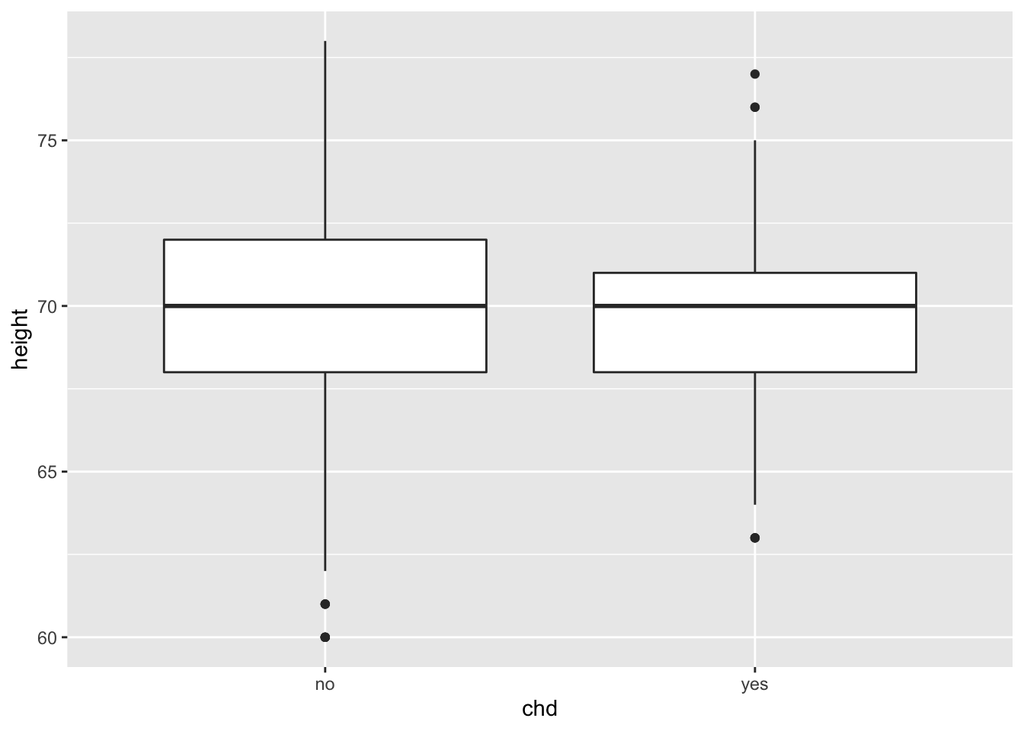

```r
ggplot(data = wcgs) +
  geom_boxplot(mapping = aes(x = chd, y = height))
```

and number of cigarretes smoked per day

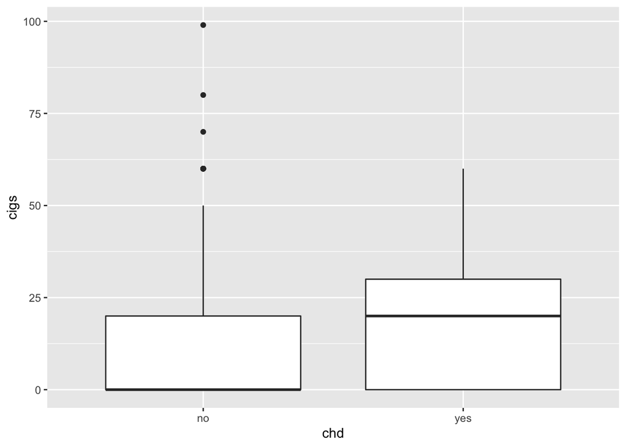

```r
ggplot(data = wcgs) +
  geom_boxplot(mapping = aes(x = chd, y = cigs))
```

It seems more cigarettes is associated with heard disease, but not height. How can we formally analyze this? If we use linear regression (straight line) for the anlaysis, the line will eventually extends beyond the [0, 1] range, making interpretation hard.

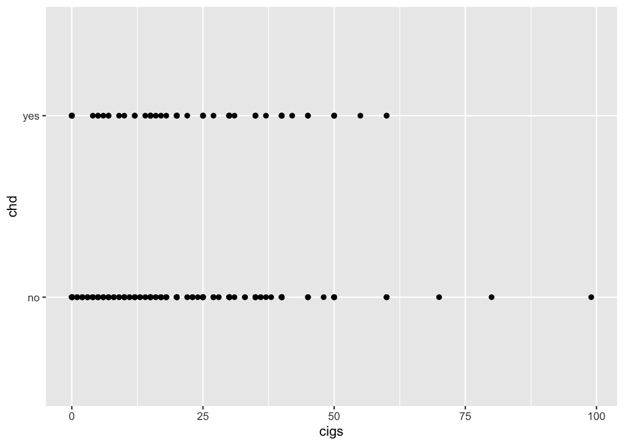

```r
ggplot(data = wcgs) +
  geom_point(mapping = aes(x = cigs, y = chd))
```

## Logistic regression

- Bernoulli model for a binary response
  $$Y_i = \begin{cases}
  1 & \text{with probability } p_i \\
  0 & \text{with probability } 1 - p_i
  \end{cases}$$
- The parameter $p_i = \mathbb{E}(Y_i)$ will be related to the predictors $X_1, \ldots, X_{q}$ via an **inverse link function**
  $$p_i = \frac{e^{\eta_i}}{1 + e^{\eta_i}},$$
  where $\eta_i$ is the **linear predictor** or **systematic component**
  $$\eta_i = \beta_0 + \beta_1 x_{i1} + \cdots + \beta_{q} x_{iq} = \mathbf{x}_i^T \boldsymbol{\beta}$$
  with
  $$\boldsymbol{\beta} = \begin{pmatrix} \beta_0 \\ \beta_1 \\ \vdots \\ \beta_q \end{pmatrix}, \quad \mathbf{x}_i = \begin{pmatrix} 1 \\ x_{i1} \\ \vdots \\ x_{iq} \end{pmatrix}.$$
- The function
  $$\eta = g(p) = \log \left( \frac{p}{1-p} \right)$$
  that links $\mathbb{E}(Y)$ to the systematic component is called the **link function**. This particular link function is also called the **logit function**.
- The function
  $$p = g^{-1}(\eta) = \frac{e^\eta}{1 + e^\eta}$$
  is called the **inverse link function**. This particular function (inverse logit) is also called the **logistic function**. A graph of the logistic function:

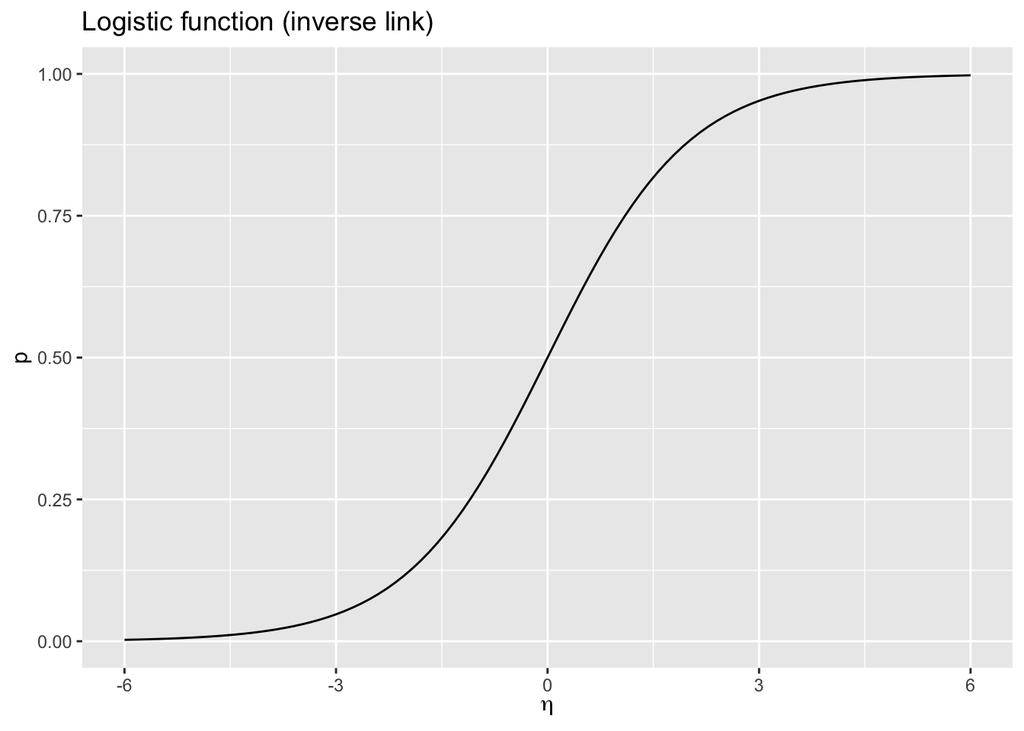

```r
ggplot(data = tibble(x = 0), mapping = aes(x = x)) + # null data
  stat_function(fun = ilogit) + # ilogit is from faraway
  xlim(-6, 6) +
  labs(x = expression(eta), y = "p", title = "Logistic function (inverse link)")
```

```r
# curve(ilogit(x), -6, 6, xlab = expression(eta), ylab = "p")
```

- Therefore above model is called the **logistic regression**.

## Fitting logistic regression

- We use **method of maximum likelihood** (MLE) to estimate the parameters $\beta_0, \ldots, \beta_q$.
- Given $n$ data points $(y_i, \mathbf{x}_i)$, $i=1,\ldots,n$, the **log-likelihood** is
  $$\begin{eqnarray*}
  \ell(\boldsymbol{\beta}) &=& \sum_i \log \left[p_i^{y_i} (1 - p_i)^{1 - y_i}\right] \\
  &=& \sum_i \left[ y_i \log p_i + (1 - y_i) \log (1 - p_i) \right] \\
  &=& \sum_i \left[ y_i \log \frac{e^{\eta_i}}{1 + e^{\eta_i}} + (1 - y_i) \log \frac{1}{1 + e^{\eta_i}} \right] \\
  &=& \sum_i \left[ y_i \eta_i - \log (1 + e^{\eta_i}) \right] \\
  &=& \sum_i \left[ y_i \cdot \mathbf{x}_i^T \boldsymbol{\beta} - \log (1 + e^{\mathbf{x}_i^T \boldsymbol{\beta}}) \right].
  \end{eqnarray*}$$
- Maximization of this log-likehood function can be carried out by the Newton-Raphson (also known as Fisher scoring) algorithm.

```r
(lmod <- glm(chd ~ height + cigs, family = binomial, wcgs))
```

```
##
## Call:  glm(formula = chd ~ height + cigs, family = binomial, data = wcgs)
##
## Coefficients:
## (Intercept)       height         cigs
##    -4.50161      0.02521      0.02313
##
## Degrees of Freedom: 3153 Total (i.e. Null);  3151 Residual
## Null Deviance:       1781
## Residual Deviance: 1749  AIC: 1755
```

Summary of the result:

```r
(lmod_sm <- summary(lmod))
```

```
##
## Call:
## glm(formula = chd ~ height + cigs, family = binomial, data = wcgs)
##
## Deviance Residuals:
##     Min       1Q   Median       3Q      Max
## -1.0041  -0.4425  -0.3630  -0.3499   2.4357
##
## Coefficients:
##             Estimate Std. Error z value Pr(>|z|)
## (Intercept) -4.50161    1.84186  -2.444   0.0145 *
## height       0.02521    0.02633   0.957   0.3383
## cigs         0.02313    0.00404   5.724 1.04e-08 ***
## ---
## Signif. codes:  0 '***' 0.001 '**' 0.01 '*' 0.05 '.' 0.1 ' ' 1
##
## (Dispersion parameter for binomial family taken to be 1)
##
##     Null deviance: 1781.2  on 3153  degrees of freedom
## Residual deviance: 1749.0  on 3151  degrees of freedom
## AIC: 1755
##
## Number of Fisher Scoring iterations: 5
```

## Interpretation

- **Exercise**: Before we attempt to interpret the results from logistic regression, we first need to understand how the data are transformed to $(y_i, \mathbf{x}_i)$.

```r
# dataframe
wcgs %>%
  select(chd, height, cigs) %>%
  head(10)
```

```
## # A tibble: 10 × 3
##    chd   height  cigs
##    <fct>  <int> <int>
##  1 no        73    25
##  2 no        70    20
##  3 no        69     0
##  4 no        68    20
##  5 yes       70    20
##  6 no        72     0
##  7 no        72     0
##  8 no        71     0
##  9 no        72    25
## 10 no        70     0
```

```r
# response
lmod$y %>% head(10)
```

```
##  1  2  3  4  5  6  7  8  9 10
##  0  0  0  0  1  0  0  0  0  0
```

```r
# predictors
model.matrix(lmod) %>% head(10)
```

```
##    (Intercept) height cigs
## 1            1     73   25
## 2            1     70   20
## 3            1     69    0
## 4            1     68   20
## 5            1     70   20
## 6            1     72    0
## 7            1     72    0
## 8            1     71    0
## 9            1     72   25
## 10           1     70    0
```

- How to interpret the regression coefficients in logistic regression? Remember
  $$\log \left( \frac{p}{1-p} \right) = \beta_0 + \beta_1 \cdot \text{height} + \beta_2 \cdot \text{cigs}.$$
  The quantity
  $$o = \frac{p}{1-p}$$
  is called **odds** (of an event).

  Therefore $\beta_1$ can be interpreted as a unit increase in $x_1$ with $x_2$ held fixed increases the **log-odds** of success by $\beta_1$, or increase the odds of success by a factor of $e^{\beta_1}$.
- The `gtsummary` package presents regression results in a much nicer way that facilitates interpretation. Summarize the log-odds:

```r
library(gtsummary)
lmod %>%
  tbl_regression() %>%
  bold_labels() %>%
  bold_p(t = 0.05)
```

| **Characteristic** | **log(OR)**<sup>1</sup> | **95% CI**<sup>1</sup> | **p-value** |
| --- | --- | --- | --- |
| height | 0.03 | -0.03, 0.08 | 0.3 |
| cigs | 0.02 | 0.02, 0.03 | <0.001 |

<sup>*1*</sup> OR = Odds Ratio, CI = Confidence Interval

Summarize the odds:

```r
lmod %>%
  tbl_regression(intercept = TRUE, exponentiate = TRUE) %>%
  bold_labels() %>%
  bold_p(t = 0.05)
```

| **Characteristic** | **OR**<sup>1</sup> | **95% CI**<sup>1</sup> | **p-value** |
| --- | --- | --- | --- |
| (Intercept) | 0.01 | 0.00, 0.40 | 0.015 |
| height | 1.03 | 0.97, 1.08 | 0.3 |
| cigs | 1.02 | 1.02, 1.03 | <0.001 |

<sup>*1*</sup> OR = Odds Ratio, CI = Confidence Interval

- **Exercise**: Interpret the regression coefficients from `wcgs` fit.

```r
# same as lmod$coefficients
# coef(lmod) is a named numeric vector
(beta_hat <- unname(coef(lmod)))
```

```
## [1] -4.50161397  0.02520779  0.02312740
```

```r
exp(beta_hat)
```

```
## [1] 0.01109108 1.02552819 1.02339691
```

How to interpret the effect of a pack a day (20 cigarettes) on heart disease?

```r
exp(beta_hat[3] * 20)
```

```
## [1] 1.588115
```

- Suppose the probability of success in the presence of some condition is $p_1$ and $p_2$ in its absence. The **relative risk** or **risk ratio** is $p_1 / p_2$. For example, the predicted probability of a 68in tall person who smokes a pack (20 cigarettes) a day and who does not smoke are, respectively

```r
(p1 <- ilogit(sum(beta_hat * c(1, 68, 20))))
```

```
## [1] 0.08907868
```

and

```r
(p2 <- ilogit(sum(beta_hat * c(1, 68, 0))))
```

```
## [1] 0.05800425
```

Then the relative risk is

```r
p1 / p2
```

```
## [1] 1.535727
```

- When the probability of event is very small (rare disease assumption), i.e., $p_1, p_2 \approx 0$, then the odds ratio is approximately equal to the risk ratio
  $$\frac{o_1}{o_2} = \frac{p_1 / (1 - p_1)}{p_2 / (1 - p_2)} \approx \frac{p_1}{p_2}.$$

## Inference (analysis of deviance)

- The **deviance** of a logistic regression fit is
  $$\begin{eqnarray*}
  D &=& 2 \sum_i \left[ y_i \log y_i + (1 - y_i) \log (1 - y_i) \right] \\
  && - 2 \sum_i \left[ y_i \log \widehat{p}_i + (1 - y_i) \log (1 - \widehat{p}_i) \right] \\
  &=& - 2 \sum_i \left[ y_i \log \widehat{p}_i + (1 - y_i) \log (1 - \widehat{p}_i) \right].
  \end{eqnarray*}$$
  It comes from the likelihood ratio test (LRT) statistic
  $$2 \log \frac{L_{\Omega}}{L_{\omega}},$$
  where $\Omega$ is the full/saturated model (same number of parameters as observations) and $\omega$ is the smaller model.
- The usual goodness of fit test using $\chi_{n-q-1}^2$ asymptotic null distribution can **not** be applied here since we only have a single observation for each predictor pattern. This is different from the binomial model in next chapter. The Hosmer-Lemeshow test partitions the predicted probailities into $J$ bins and then carries out a Pearson $X^2$ type test to assess the goodness of fit (ELMR 2.6).
- In the model output, the **residual deviance**, denoted $D_L$, is the devience of the current model and the *null deviance*, denoted $D_S$, is the deviance of the model with just an intercept term. Assuming the null model, the test statistic $D_S - D_L$ is asymptotically distributed $\chi_{\ell - s}^2$. In our case, the test statistic is

```r
lmod$null.deviance - lmod$deviance
```

```
## [1] 32.19451
```

giving p-value

```r
pchisq(lmod$null.deviance - lmod$deviance, 2, lower.tail = FALSE)
```

```
## [1] 1.02106e-07
```

Therefore our model gives a significantly better fit than the null (intercept-only) model.

- We can also test the significance of individual predictor using analysis of deviance (`anova` function). For example, is `height` necessary in the model?

```r
# fit a model without height
lmodc <- glm(chd ~ cigs, family = binomial, wcgs)
anova(lmodc, lmod, test = "Chi")
```

```
## Analysis of Deviance Table
##
## Model 1: chd ~ cigs
## Model 2: chd ~ height + cigs
##   Resid. Df Resid. Dev Df Deviance Pr(>Chi)
## 1      3152       1750
## 2      3151       1749  1  0.92025   0.3374
```

- Similar to linear regression, the convenience function `drop1` tests each individual predictor in one shot.

```r
drop1(lmod, test = "Chi")
```

```
## Single term deletions
##
## Model:
## chd ~ height + cigs
##        Df Deviance    AIC     LRT Pr(>Chi)
## <none>      1749.0 1755.0
## height  1   1750.0 1754.0  0.9202   0.3374
## cigs    1   1780.1 1784.1 31.0695 2.49e-08 ***
## ---
## Signif. codes:  0 '***' 0.001 '**' 0.01 '*' 0.05 '.' 0.1 ' ' 1
```

- The coefficient test from summary is based on the z-value $\hat \beta_j / \text{se}(\hat{\beta}_j)$.

```r
lmod_sm$coefficients
```

```
##                Estimate  Std. Error   z value     Pr(>|z|)
## (Intercept) -4.50161397 1.841862743 -2.444055 1.452321e-02
## height       0.02520779 0.026327385  0.957474 3.383281e-01
## cigs         0.02312740 0.004040183  5.724344 1.038339e-08
```

In general, deviance-based test is preferred over the z-test.

## Confidence intervals

- Confidence interval can be constructed either from normal approximation
  $$\hat \beta_j \pm z^{\alpha / 2} \text{se}(\hat \beta_j)$$

```r
tibble(
  `coef`  = beta_hat,
  `2.5%`  = beta_hat - 1.96 * lmod_sm$coefficients[, 2],
  `97.5%` = beta_hat + 1.96 * lmod_sm$coefficients[, 2])
```

```
## # A tibble: 3 × 3
##      coef  `2.5%` `97.5%`
##     <dbl>   <dbl>   <dbl>
## 1 -4.50   -8.11   -0.892
## 2  0.0252 -0.0264  0.0768
## 3  0.0231  0.0152  0.0310
```

or from profile-likelihood

```r
confint(lmod)
```

```
##                   2.5 %      97.5 %
## (Intercept) -8.13475465 -0.91297018
## height      -0.02619902  0.07702835
## cigs         0.01514949  0.03100534
```

## Diagnostics

- There are two kinds of fitted values (or predicted values). The first is on the scale of the linear predictor, $\eta$,

```r
linpred  <- predict(lmod)
linpred %>% head(10)
```

```
##         1         2         3         4         5         6         7         8
## -2.083261 -2.274521 -2.762277 -2.324936 -2.274521 -2.686653 -2.686653 -2.711861
##         9        10
## -2.108468 -2.737069
```

The second on the scale of response, $p = \text{logit}^{-1}(\eta)$,

```r
predprob <- predict(lmod, type = "response")
predprob %>% head(10)
```

```
##          1          2          3          4          5          6          7
## 0.11073449 0.09325523 0.05939705 0.08907868 0.09325523 0.06376553 0.06376553
##          8          9         10
## 0.06227708 0.10827647 0.06082112
```

- We compute the **raw residuals**
  $$y - \widehat{p}$$

```r
# same as residuals(lmod, type = "response")
rawres <- lmod$y - predprob
```

The plot of raw residuals against the fitted values is not very informative.

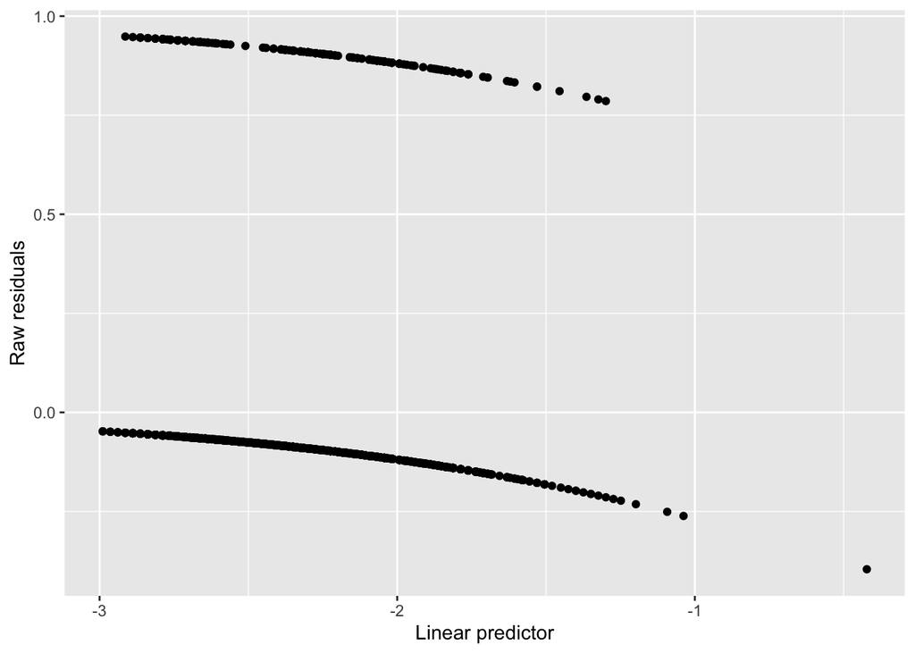

```r
wcgs %>%
  mutate(rawres = rawres, linpred = linpred) %>%
  ggplot() +
  geom_point(mapping = aes(x = linpred, y = rawres)) +
  labs(x = "Linear predictor", y = "Raw residuals")
```

We do not expect the raw residuals to have equal variance because the binary variance is $p(1 - p)$.

- The **deviance residuals** are standardized residuals defined by
  $$d_i = \text{sign}(y_i - \widehat{p}_i) \sqrt{-2 [y_i \log\widehat{p}_i + (1 - y_i) \log(1 - \widehat{p}_i)]}.$$
  Note
  $$\sum_i d_i^2 = \text{deviance}$$
  in analogy to $\sum_i \widehat{\epsilon}_i^2 = \text{RSS}$ in linear regression. The term $\text{sign}(y_i - \widehat{p}_i)$ ensures that $d_i$ has the same sign as raw residual $y_i - \widehat{p}_i$.

```r
devres <- residuals(lmod)
devres %>% head(10)
```

```
##          1          2          3          4          5          6          7
## -0.4844779 -0.4424800 -0.3499548 -0.4319693  2.1782631 -0.3630133 -0.3630133
##          8          9         10
## -0.3586106 -0.4787466 -0.3542579
```

Sanity check:

```r
sqrt(-2 * (lmod$y * log(predprob) + (1 - lmod$y) * log(1 - predprob))) %>%
  head(10)
```

```
##         1         2         3         4         5         6         7         8
## 0.4844779 0.4424800 0.3499548 0.4319693 2.1782631 0.3630133 0.3630133 0.3586106
##         9        10
## 0.4787466 0.3542579
```

The plot of deviance residuals against the fitted values.

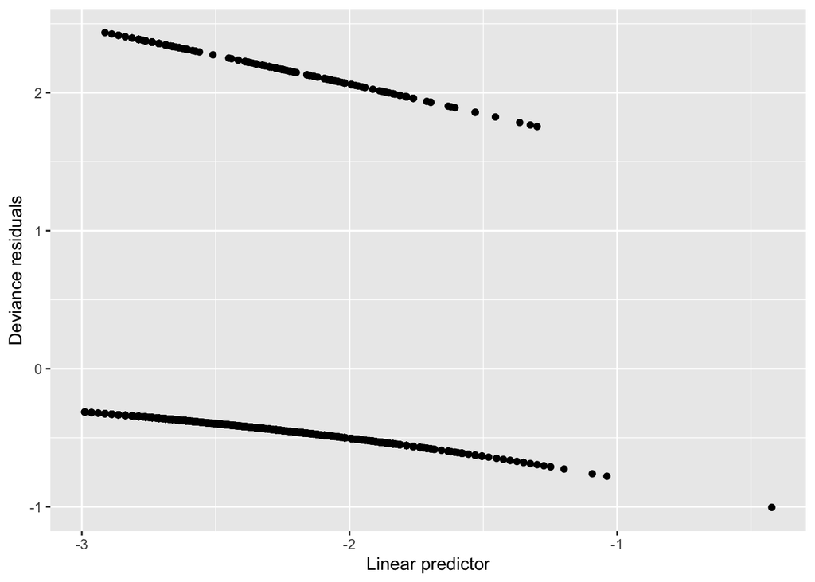

```r
wcgs %>%
  mutate(devres = devres, linpred = linpred) %>%
  ggplot() +
  geom_point(mapping = aes(x = linpred, y = devres)) +
  labs(x = "Linear predictor", y = "Deviance residuals")
```

Again we see the residuals are clustered into two lines: the upper one corresponding to $y_i=1$ and the lower one to $y_i=0$. We can improve this plot by binning: divide the range of linear predictor into 100 bins of roughly equal points and plot average residual against average linear predictors per bin.

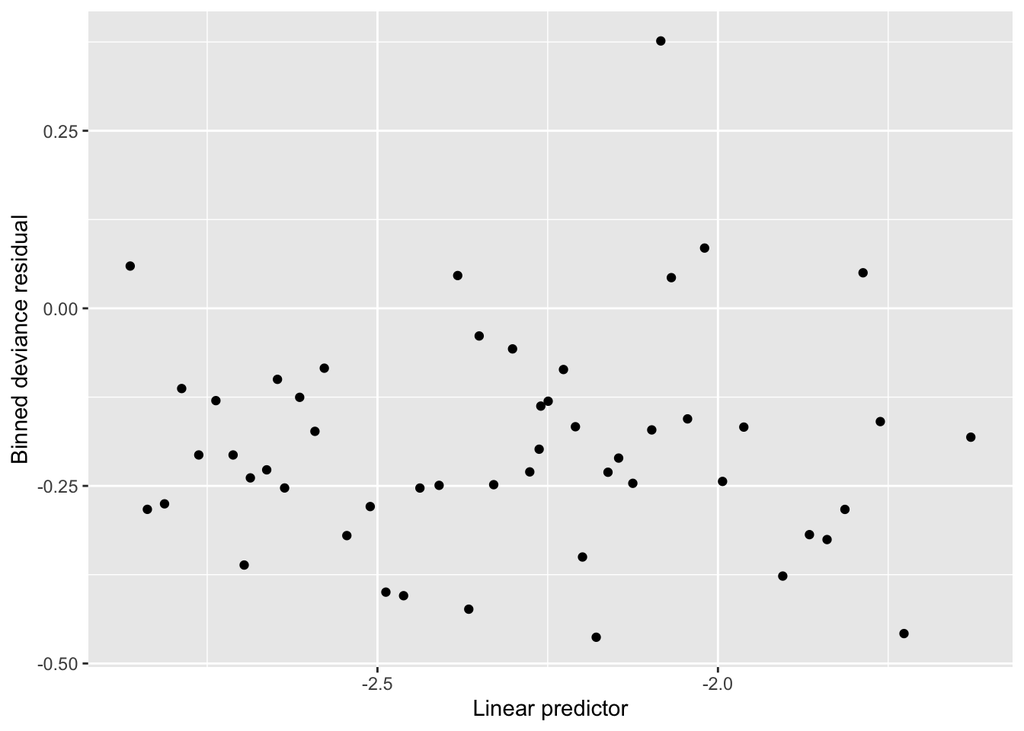

```r
wcgs %>%
  mutate(devres = devres, linpred = linpred) %>%
  group_by(cut(linpred, breaks = unique(quantile(linpred, (1:100)/101)))) %>%
  summarize(devres = mean(devres),
            linpred = mean(linpred)) %>%
  ggplot() +
  geom_point(mapping = aes(x = linpred, y = devres)) +
  labs(x = "Linear predictor", y = "Binned deviance residual")
```

**Question**: is there a concern that the deviance residuals are not centered around 0?

- QQ plot is not helpful since there is no reason these deviance residuals are approximately standard normal.

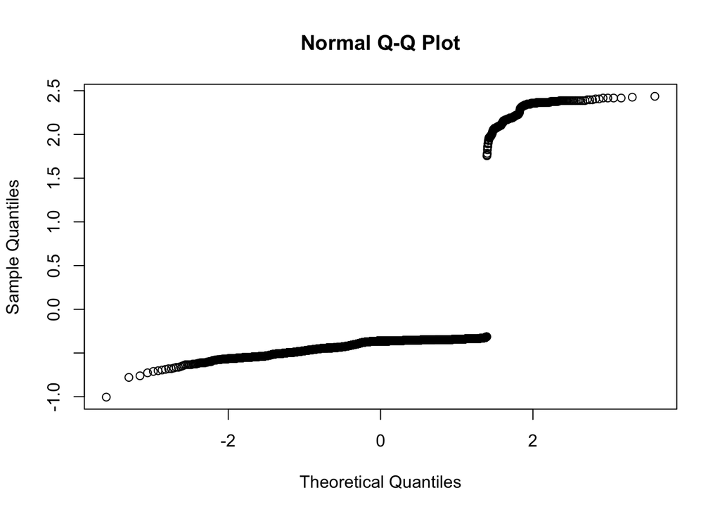

```r
qqnorm(devres)
```

- Half-normal plot (hat values against half-normal quantiles) can help detect unusual cases in predictor space (high leverage cases). For logistic regression, we use the generalized hat matrix
  $$\mathbf{H} = \widehat{\mathbf{W}}^{1/2} \mathbf{X}^T (\mathbf{X}^T \widehat{\mathbf{W}} \mathbf{X})^{-1} \mathbf{X} \widehat{\mathbf{W}}^{1/2},$$
  where
  $$\widehat{\mathbf{W}} = \begin{pmatrix}
  \widehat{p}_1 (1 - \widehat{p}_1) & \\
  & \ddots & \\
  & & \widehat{p}_n (1 - \widehat{p}_n)
  \end{pmatrix}.$$

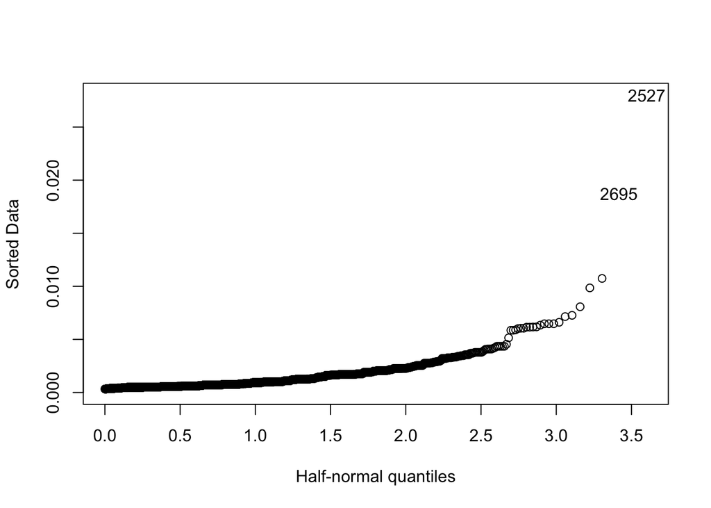

```r
halfnorm(hatvalues(lmod))
```

We see two high leverage cases, who smoke an unusual number of cigarettes per day!

```r
wcgs %>%
  slice(c(2527, 2695)) %>%
  print(width = Inf)
```

```
## # A tibble: 2 × 13
##     age height weight   sdp   dbp  chol behave  cigs dibep chd   typechd timechd
##   <int>  <int>  <int> <int> <int> <int> <fct>  <int> <fct> <fct> <fct>     <int>
## 1    52     71    168   120    80   251 A1        99 B     no    none       2956
## 2    47     64    158   116    76   206 A1        80 B     no    none       2114
##   arcus
##   <fct>
## 1 present
## 2 absent
```

- Plot of Cook distance against half-normal quantiles may reveal high influential points (high residual combined with high leverage) cases.

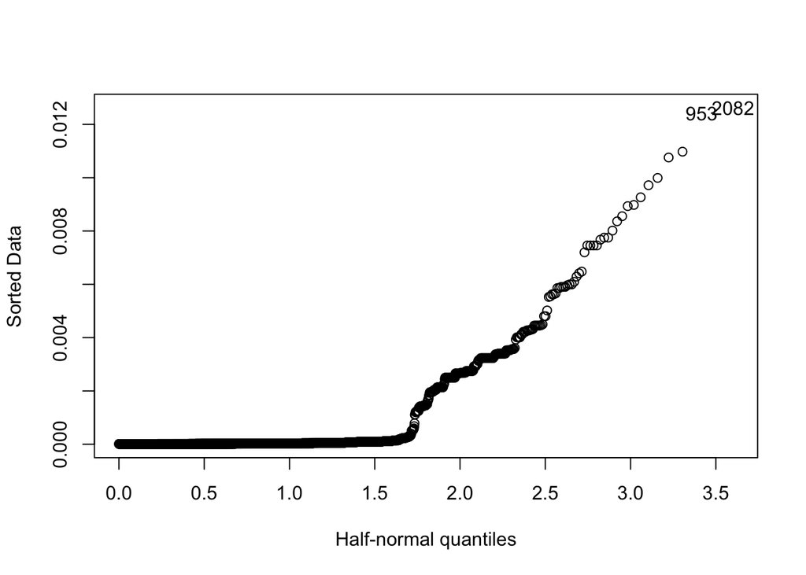

```r
halfnorm(cooks.distance(lmod))
```

```r
wcgs %>%
  slice(c(953, 2082)) %>%
  print(width = Inf)
```

```
## # A tibble: 2 × 13
##     age height weight   sdp   dbp  chol behave  cigs dibep chd   typechd timechd
##   <int>  <int>  <int> <int> <int> <int> <fct>  <int> <fct> <fct> <fct>     <int>
## 1    57     63    155   128    88   196 A2         0 B     yes   silent     2349
## 2    49     77    210   138    86   235 B3         0 A     yes   angina     3048
##   arcus
##   <fct>
## 1 absent
## 2 absent
```

## Goodness of fit

### Hosmer-Lemeshow statistic

- Intuitively if we divide observations into $J$ bins according to linear predictors $\eta$, then $y_j / n_j$ (observed proportion of “successes”) for $j$-th bin should be close to the average predicted probabilities in that bin.

```r
wcgs_binned <- wcgs %>%
  mutate(predprob = predict(lmod, type = "response"),
         linpred  = predict(lmod, type = "link"),
         bin      = cut(linpred, breaks = unique(quantile(linpred, (1:100) / 101)))) %>%
  group_by(bin) %>%
  summarize(y       = sum(ifelse(chd == "yes", 1, 0)),
            avgpred = mean(predprob),
            count   = n()) %>%
  mutate(se_fit = sqrt(avgpred * (1 - avgpred) / count))
```

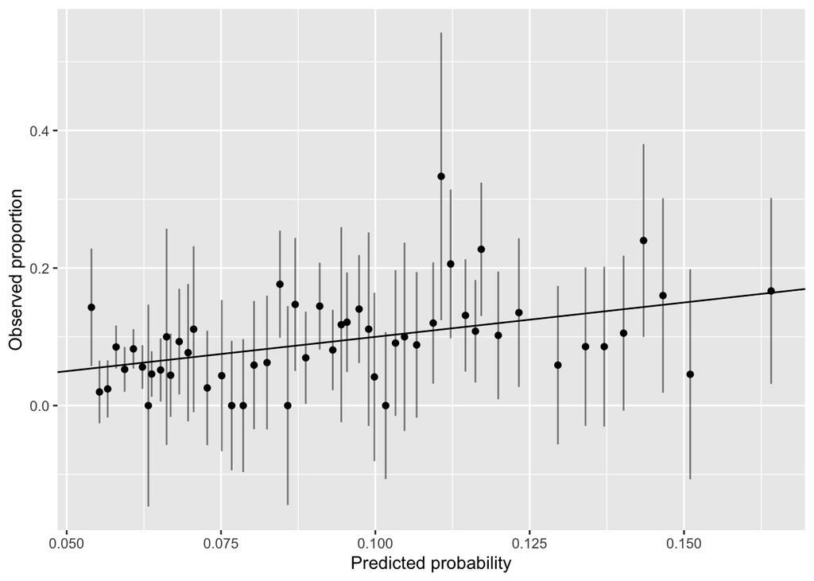

```r
wcgs_binned %>%
  ggplot(mapping = aes(x = avgpred, y = y / count)) +
  geom_point() +
  geom_linerange(mapping = aes(ymin = y / count - 2 * se_fit,
                               ymax = y / count + 2 * se_fit), alpha = 0.5) +
  geom_abline(intercept = 0, slope = 1) +
  labs(x = "Predicted probability", y = "Observed proportion")
```

- The Hosmer-Lemeshow test formalizes this idea by testing the statistic
  $$X_{\text{HL}}^2 = \sum_{j=1}^J \frac{(y_i - m_j \widehat{p}_j)^2}{m_j \widehat{p}_j (1 - \widehat{p}_j)}$$
  against the $\chi^2$ distribution with $J-1$ degrees of freedom.

```r
# Hosmer-Lemeshow test statistic
(hlstat <- with(wcgs_binned, sum((y - count * avgpred)^2 / (count * avgpred * (1 - avgpred)))))
```

```
## [1] 64.87001
```

```r
# J
nrow(wcgs_binned)
```

```
## [1] 52
```

```r
# p-value
pchisq(hlstat, nrow(wcgs_binned) - 1, lower.tail = FALSE)
```

```
## [1] 0.09172918
```

We see a moderate p-value, which indicates no lack of fit.

### ROC curve

- Logistic regression is often used as a tool for **classification**.
- If we choose a threshold, say 0.2, then the predicted probabilities give a classification rule
  $$\text{case $i$ is a} \begin{cases}
  \text{"success"} & \text{if } \widehat{p}_i \ge 0.2 \\
  \text{"failure"} & \text{if } \widehat{p}_i < 0.2
  \end{cases}.$$

```r
wcgs %>%
  mutate(predprob = predict(lmod, type = "response")) %>%
  mutate(predout = ifelse(predprob >= 0.2, "yes", "no")) %>%
  xtabs(~ chd + predout, data = .)
```

```
##      predout
## chd     no  yes
##   no  2886   11
##   yes  254    3
```

- With this classification rule, we see the error rate is about

```r
(11 + 254) / (2886 + 254 + 11 + 3)
```

```
## [1] 0.08402029
```

[figure not shown]

The **sensitivity** is
$$\frac{\text{TP}}{\text{TP + FN}} = \frac{3}{257} = 1.17\%$$
and the **specificity** is
$$\frac{\text{TN}}{\text{FP + TN}} = \frac{2886}{11 + 2886} = 99.62\%$$

- If we lower the threshold, then we increase the sensitivity but decrease the specificity. If we plot sensitivity against 1-specificity by varying the threshold, then we get the **receiver operating characteristic (ROC)** curve.

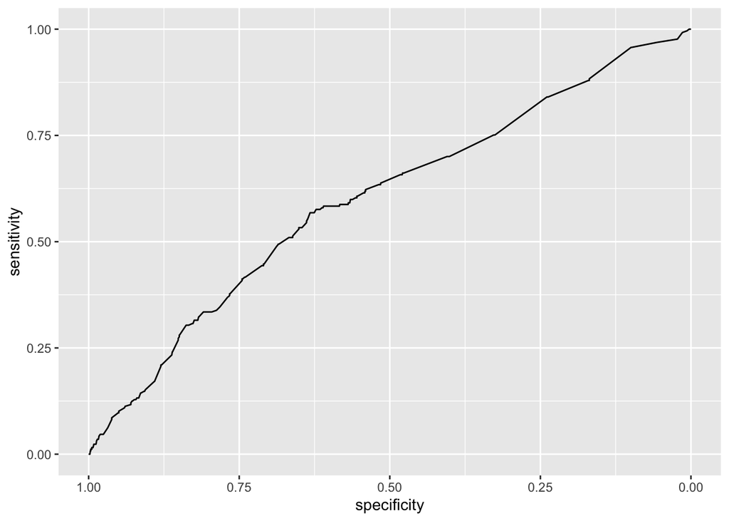

```r
library(pROC)
lmod_roc <- roc(chd ~ predprob, wcgs)
ggroc(lmod_roc)
```

The area under the curve (AUC) is a measure of the overal classification of the classifier. Larger AUC means better classification performance.

```r
auc(lmod_roc)
```

```
## Area under the curve: 0.6007
```

## Model selection by AIC

- We can perform sequential search using the Akaike information criterion (AIC)
  $$\text{AIC} = \text{deviance} + 2q.$$
  We start from a rich enough model

```r
wcgs <- wcgs %>%
  # 1 in = 0.0254 m, 1 lb = 0.4536 kg
  mutate(bmi = 703 * weight / height)
biglm <- glm(chd ~ age + height + weight + bmi + sdp + dbp + chol + dibep + cigs + arcus,
             family = binomial, data = wcgs)
```

and then do sequential backward search using the `step` function

```r
step(biglm, trace = TRUE, direction = "both") %>%
  tbl_regression() %>%
  bold_labels()
```

```
## Start:  AIC=1591.05
## chd ~ age + height + weight + bmi + sdp + dbp + chol + dibep +
##     cigs + arcus
##
##          Df Deviance    AIC
## - dbp     1   1569.1 1589.1
## - weight  1   1569.3 1589.3
## - bmi     1   1569.5 1589.5
## - height  1   1569.5 1589.5
## <none>        1569.0 1591.0
## - arcus   1   1571.1 1591.1
## - sdp     1   1576.8 1596.8
## - dibep   1   1590.4 1610.4
## - cigs    1   1592.0 1612.0
## - age     1   1593.7 1613.7
## - chol    1   1619.8 1639.8
##
## Step:  AIC=1589.06
## chd ~ age + height + weight + bmi + sdp + chol + dibep + cigs +
##     arcus
##
##          Df Deviance    AIC
## - weight  1   1569.4 1587.4
## - bmi     1   1569.5 1587.5
## - height  1   1569.5 1587.5
## <none>        1569.1 1589.1
## - arcus   1   1571.2 1589.2
## + dbp     1   1569.0 1591.0
## - sdp     1   1586.2 1604.2
## - dibep   1   1590.4 1608.4
## - cigs    1   1592.5 1610.5
## - age     1   1593.7 1611.7
## - chol    1   1619.9 1637.9
##
## Step:  AIC=1587.36
## chd ~ age + height + bmi + sdp + chol + dibep + cigs + arcus
##
##          Df Deviance    AIC
## - height  1   1570.3 1586.3
## <none>        1569.4 1587.4
```

[output cut: 10 more lines]

```
## Step:  AIC=1586.32
## chd ~ age + bmi + sdp + chol + dibep + cigs + arcus
##
##          Df Deviance    AIC
## <none>        1570.3 1586.3
## - arcus   1   1572.6 1586.6
## + height  1   1569.4 1587.4
## + weight  1   1569.5 1587.5
## + dbp     1   1570.3 1588.3
## - bmi     1   1577.3 1591.3
## - sdp     1   1587.2 1601.2
## - dibep   1   1591.9 1605.9
## - age     1   1594.2 1608.2
## - cigs    1   1594.6 1608.6
## - chol    1   1620.0 1634.0
```

| **Characteristic** | **log(OR)**<sup>1</sup> | **95% CI**<sup>1</sup> | **p-value** |
| --- | --- | --- | --- |
| age | 0.06 | 0.04, 0.08 | <0.001 |
| bmi | 0.00 | 0.00, 0.00 | 0.008 |
| sdp | 0.02 | 0.01, 0.03 | <0.001 |
| chol | 0.01 | 0.01, 0.01 | <0.001 |
| dibep |  |  |  |
| A | — | — |  |
| B | 0.66 | 0.38, 1.0 | <0.001 |
| cigs | 0.02 | 0.01, 0.03 | <0.001 |
| arcus |  |  |  |
| absent | — | — |  |
| present | 0.22 | -0.06, 0.50 | 0.13 |

<sup>*1*</sup> OR = Odds Ratio, CI = Confidence Interval

## Model selection by lasso

- A modern approach for model selection is the **lasso**, which minimizes the function
  $$- n^{-1} \ell(\boldsymbol{\beta}) + \lambda \sum_{j=1}^q |\beta_j|,$$
  where $\ell(\boldsymbol{\beta})$ is the log-likelihood of logistic regression and $\lambda>0$ is a tuning parameter. We notice that
  - when $\lambda = \infty$, all non-intercept regression coefficients will be pushed to 0, and
  - when $\lambda = 0$, the regression coefficients are same as those from regular logistic regression.  
    If we vary $\lambda$ from 0 to larger values, we will obtain intermediate models with lesser and lesser preditors. This way we are achieving continuous model selection.
- For details of `glmnet` package, see the vignette at https://web.stanford.edu/~hastie/glmnet/glmnet_alpha.html
- How do we choose $\lambda$, which determines the model size? One natural idea is to split the data into a training set and a validation set. The **training set** is used to fit the logistic regression at different $\lambda$ values. Then the **validation set** is used to evaluate and compare the performance of different models. We will choose the model that gives the best performance on the validation set.
- First let’s remove cases with missing values

```r
(wcgs <- wcgs %>%
  select(-c(behave, typechd, timechd)) %>%
  drop_na())
```

```
## # A tibble: 3,140 × 11
##      age height weight   sdp   dbp  chol  cigs dibep chd   arcus     bmi
##    <int>  <int>  <int> <int> <int> <int> <int> <fct> <fct> <fct>   <dbl>
##  1    49     73    150   110    76   225    25 B     no    absent  1445.
##  2    42     70    160   154    84   177    20 B     no    present 1607.
##  3    42     69    160   110    78   181     0 A     no    absent  1630.
##  4    41     68    152   124    78   132    20 A     no    absent  1571.
##  5    59     70    150   144    86   255    20 A     yes   present 1506.
##  6    44     72    204   150    90   182     0 A     no    absent  1992.
##  7    44     72    164   130    84   155     0 A     no    absent  1601.
##  8    40     71    150   138    60   140     0 B     no    absent  1485.
##  9    43     72    190   146    76   149    25 A     no    absent  1855.
## 10    42     70    175   132    90   325     0 B     no    present 1758.
## # … with 3,130 more rows
```

split data into 80% training cases and 20% validation cases.

```r
library(glmnet)
library(caret)
# set seed for reproducibility
set.seed(200)

# list = FALSE, request result to be in a matrix (of row position) not a list
training_samples <- wcgs$chd %>%
  createDataPartition(p = 0.8, list = FALSE)
# (train_data <- wcgs %>%
#   slice(training_samples[, 1]))
# (val_data   <- wcgs %>%
#   slice(-training_samples[, 1]))
```

The `glmnet` package takes a matrix (of predictors) and a vector (of responses) as input. We use `model.matrix` function to create them. `glmnet` will add intercept by default, so we drop intercept term when forming `x` matrix.

```r
# X and y from original data
x_all <- model.matrix(
  chd ~ - 1 + age + height + weight + bmi + sdp + dbp + chol + dibep + cigs + arcus,
  data = wcgs)
y_all <- ifelse(wcgs$chd == "yes", 1, 0)
# training X and y
x_train <- x_all[training_samples[, 1], ]
y_train <- y_all[training_samples[, 1]]
# validation X and y
x_val <- x_all[-training_samples[, 1], ]
y_val <- y_all[-training_samples[, 1]]
```

Fit lasso regression and plot solution path:

```r
lasso_fit <- glmnet(x_train, y_train, family = "binomial", alpha = 1)
summary(lasso_fit)
```

```
##            Length Class     Mode
## a0          49    -none-    numeric
## beta       539    dgCMatrix S4
## df          49    -none-    numeric
## dim          2    -none-    numeric
## lambda      49    -none-    numeric
## dev.ratio   49    -none-    numeric
## nulldev      1    -none-    numeric
## npasses      1    -none-    numeric
## jerr         1    -none-    numeric
## offset       1    -none-    logical
## classnames   2    -none-    character
## call         5    -none-    call
## nobs         1    -none-    numeric
```

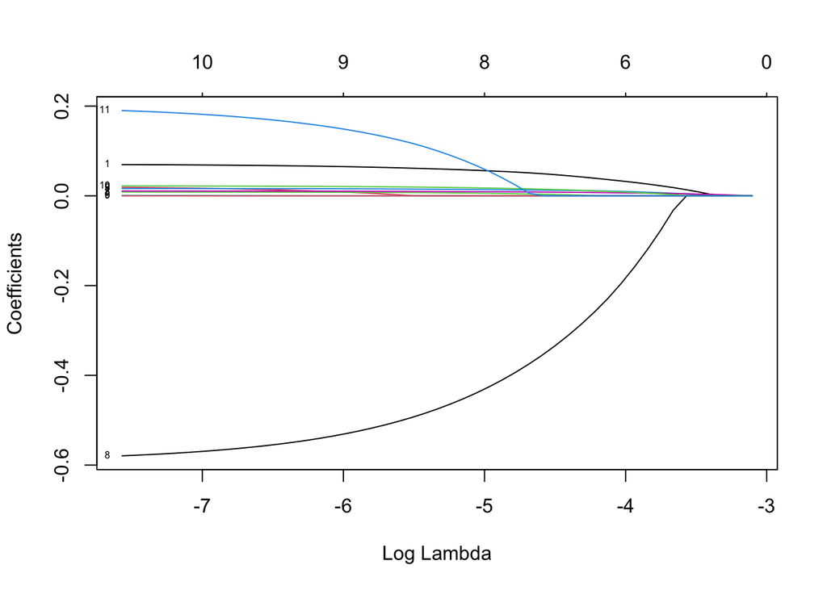

```r
plot(lasso_fit, xvar = "lambda", label = TRUE)
```

- Here
  - $\alpha = 1$ corresponds to the lasso regression, in the family of **elastic net penalties**
    $$(1 - \alpha) \|\boldsymbol{\beta}\|_2^2 / 2 + \alpha \|\boldsymbol{\beta}\|_1.$$
  - Other choises for `xvar` are `"lambda"` for log lambda value, `"norm"` for the $\ell_1$-norm of the coefficients (default), and `"dev"` for the percentage of deviance explained.
- Now we can evaluate the performance of the models (corresponding to different $\lambda$ values) on the validation set.

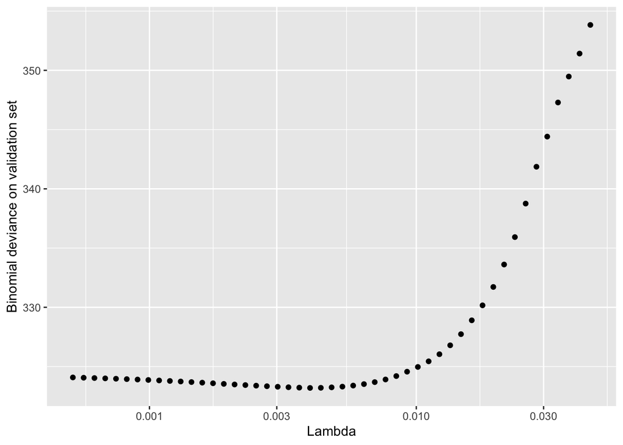

```r
# predict validation case probabilities at different \lambda values and calculate test deviance
pred_val <- predict(lasso_fit, newx = x_val, type = "response", s = lasso_fit$lambda)
dev_val <- -2 * colSums(y_val * log(pred_val) + (1 - y_val) * log(1 - pred_val))
tibble(lambda = lasso_fit$lambda, dev_val = dev_val) %>%
  ggplot() +
  geom_point(mapping = aes(x = lambda, y = dev_val)) +
  scale_x_log10() +
  labs(y = "Binomial deviance on validation set", x = "Lambda")
```

From the graph, it seems that $\lambda = 0.005$ yields a model that performs best on the validation set.

- Now the question is whether we should make decision on this single training-validation split? A common strategy is to use **cross validation**.

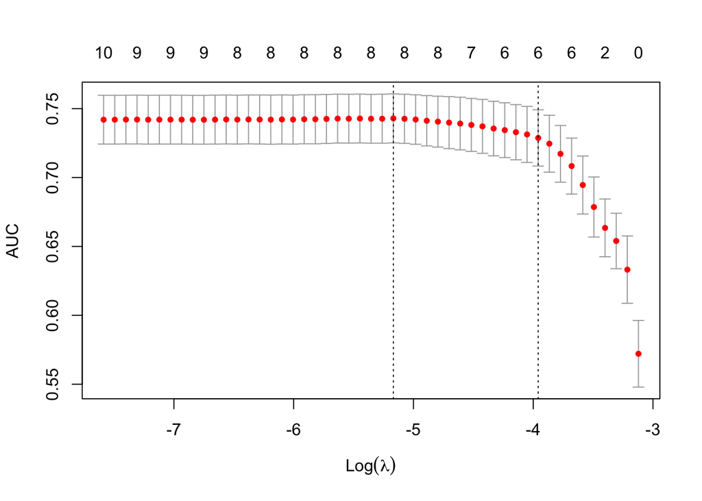

```r
set.seed(200)
cv_lasso <- cv.glmnet(x_all, y_all, alpha = 1, family = "binomial",
                      type.measure = "auc")
plot(cv_lasso)
```

```r
cv_lasso$lambda.min
```

```
## [1] 0.005696827
```

```r
coef(cv_lasso, cv_lasso$lambda.min)
```

```
## 12 x 1 sparse Matrix of class "dgCMatrix"
##                         s1
## (Intercept)  -9.893281e+00
## age           4.954011e-02
## height        .
## weight        5.334625e-03
## bmi           .
## sdp           1.537576e-02
## dbp           .
## chol          9.228292e-03
## dibepA       -5.162308e-01
## dibepB        2.725036e-14
## cigs          1.656021e-02
## arcuspresent  9.149817e-02
```

We see that this model differs from the best model chosen by AIC by replacing the predictor `bmi` by `weight`.